# Practical Machine Learning Wk4 Assignment

manifits

March 8, 2017

# Background

Using devices such as Jawbone Up, Nike FuelBand, and Fitbit it is now possible to collect a large amount of data about personal activity relatively inexpensively. One thing that people regularly do is quantify how much of a particular activity they do, but they rarely quantify how well they do it.

In this project, the goal is to use data from accelerometers on the belt, forearm, arm, and dumbell of 6 participants. They were asked to perform barbell lifts correctly and incorrectly in 5 different ways. More information is available from the website: http://groupware.les.inf.puc-rio.br/har (see the section on the Weight Lifting Exercise Dataset).

# Load and clean the data

Load the training and testing data from the given links. We will then remove mostly zero columns and unrelevant variables from the data set. We also remove near zero variance variables as they have very few unique values relative to the number of samples and may not make good predictors.

```r
filename1 <- "training.csv"
filename2 <- "testing.csv"

if (!file.exists(filename1)){
  fileURL <- "https://d396qusza40orc.cloudfront.net/predmachlearn/pml-training.csv"
  download.file(fileURL, filename1)
}
training <- read.csv("training.csv", na.strings=c("NA", ""))

if (!file.exists(filename2)){
  fileURL <- "https://d396qusza40orc.cloudfront.net/predmachlearn/pml-testing.csv"
  download.file(fileURL, filename2)
}
testing <- read.csv("testing.csv", na.strings=c("NA", ""))

dim(training)
```

```
## [1] 19622   160
```

```r
dim(testing)
```

```
## [1]  20 160
```

```r
# Remove variables that are mostly (>90%) NAs from the training set
training1 <- training[,colSums(!is.na(training))>nrow(training)*0.9]
dim(training1)
```

```
## [1] 19622    60
```

```r
# Remove unrelevant variables like index, user name, time stamps and windows, i.e. columns 1 to 7
training1 <- training1[,-c(1:7)]
dim(training1)
```

```
## [1] 19622    53
```

```r
# Remove Near Zero Variance predictors as they have very few unique values relative to the number of samples
library(caret)
nearZeroVar(training1, freqCut=95/5, saveMetrics = FALSE)
```

```
## integer(0)
```

```r
dim(training1)
```

```
## [1] 19622    53
```

The last step did not remove additional variables. We have a total of 52 variables to predict classe (which is the 53rd column of the dataset.)

# Split training data and keep testing data for validation

```r
# Partition training data into training set to build the model and testing set to predict and test model accuracy.
set.seed(123)
inTrain = createDataPartition(training1$classe, p=0.60, list=FALSE)
train1 = training1[inTrain,]
test1 = training1[-inTrain,]
dim(train1)
```

```
## [1] 11776    53
```

```r
dim(test1)
```

```
## [1] 7846   53
```

# Build the model

I will fit the following three models on the training set and check which provides the best out-of-sample accuracy with the testing set:  
1. CART - classificaiton and regression tree, “rpart”  
2. GBM - Gradient boosting machine, “gbm”  
3. Random Forest - “rf”

I will use k fold cross validation with k=5.

```r
fitControl <- trainControl(method="cv", number=5)

# (1) CART model
library(rpart)
library(rattle)
modCART <- train(classe ~., method="rpart", data=train1)
print(modCART$finalModel)
```

```
## n= 11776
##
## node), split, n, loss, yval, (yprob)
##       * denotes terminal node
##
##  1) root 11776 8428 A (0.28 0.19 0.17 0.16 0.18)
##    2) roll_belt< 130.5 10776 7434 A (0.31 0.21 0.19 0.18 0.11)
##      4) pitch_forearm< -33.95 956    7 A (0.99 0.0073 0 0 0) *
##      5) pitch_forearm>=-33.95 9820 7427 A (0.24 0.23 0.21 0.2 0.12)
##       10) yaw_belt>=169.5 478   47 A (0.9 0.046 0 0.042 0.01) *
##       11) yaw_belt< 169.5 9342 7092 B (0.21 0.24 0.22 0.2 0.12)
##         22) magnet_dumbbell_z< -93.5 1104  447 A (0.6 0.28 0.043 0.058 0.023) *
##         23) magnet_dumbbell_z>=-93.5 8238 6231 C (0.16 0.24 0.24 0.22 0.14)
##           46) pitch_belt< -42.95 491   75 B (0.014 0.85 0.084 0.026 0.029) *
##           47) pitch_belt>=-42.95 7747 5781 C (0.17 0.2 0.25 0.24 0.15)
##             94) magnet_dumbbell_y< 290.5 3437 2046 C (0.19 0.12 0.4 0.16 0.12) *
##             95) magnet_dumbbell_y>=290.5 4310 3032 D (0.15 0.26 0.13 0.3 0.16) *
##    3) roll_belt>=130.5 1000    6 E (0.006 0 0 0 0.99) *
```

[figure not shown]

```r
fancyRpartPlot(modCART$finalModel)
```

```r
# (2) Gradient boosting machine model
set.seed(123)
library(gbm)
modGBM <- train(classe ~., method="gbm", trControl=fitControl, data=train1, verbose=FALSE)
modGBM
```

```
## Stochastic Gradient Boosting
##
## 11776 samples
##    52 predictor
##     5 classes: 'A', 'B', 'C', 'D', 'E'
##
## No pre-processing
## Resampling: Cross-Validated (5 fold)
## Summary of sample sizes: 9421, 9420, 9422, 9420, 9421
## Resampling results across tuning parameters:
##
##   interaction.depth  n.trees  Accuracy   Kappa
##   1                   50      0.7567056  0.6916714
##   1                  100      0.8182724  0.7699826
##   1                  150      0.8485883  0.8083531
##   2                   50      0.8533439  0.8141331
##   2                  100      0.9059945  0.8810203
##   2                  150      0.9317245  0.9135999
##   3                   50      0.8950406  0.8670820
##   3                  100      0.9412357  0.9256379
##   3                  150      0.9577951  0.9466021
##
## Tuning parameter 'shrinkage' was held constant at a value of 0.1
##
## Tuning parameter 'n.minobsinnode' was held constant at a value of 10
## Accuracy was used to select the optimal model using  the largest value.
## The final values used for the model were n.trees = 150,
##  interaction.depth = 3, shrinkage = 0.1 and n.minobsinnode = 10.
```

```r
# (3) Random forest model with all predictors
library(randomForest)
modRF <- randomForest(classe~., method="rf", importance=TRUE, ntree=100, data=train1)
modRF
```

```
##
## Call:
##  randomForest(formula = classe ~ ., data = train1, method = "rf",      importance = TRUE, ntree = 100)
##                Type of random forest: classification
##                      Number of trees: 100
## No. of variables tried at each split: 7
##
##         OOB estimate of  error rate: 0.77%
## Confusion matrix:
##      A    B    C    D    E class.error
## A 3343    4    0    0    1 0.001493429
## B   14 2260    5    0    0 0.008336990
## C    1   21 2022   10    0 0.015579357
## D    1    0   24 1903    2 0.013989637
## E    1    0    1    6 2157 0.003695150
```

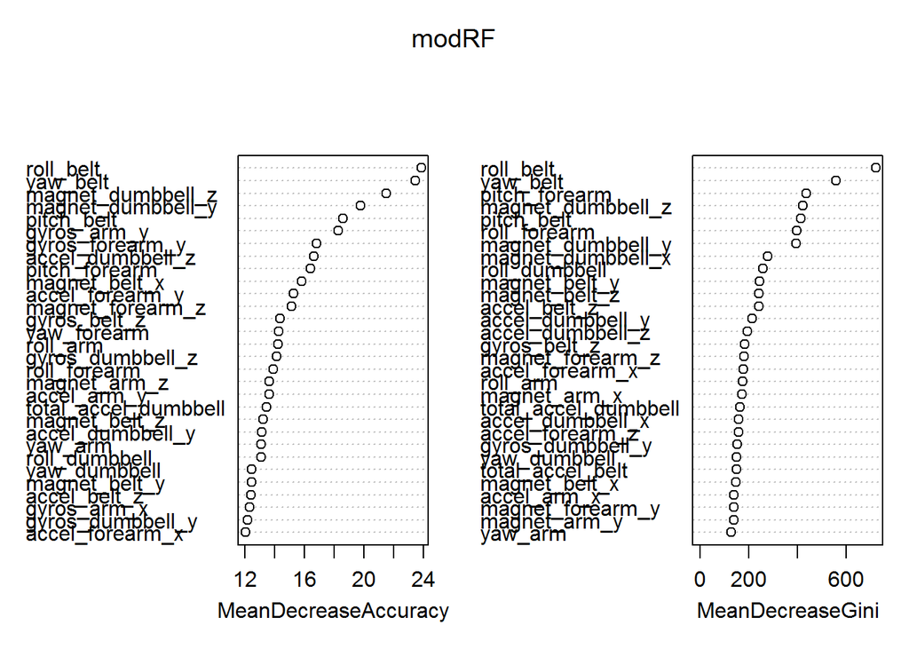

```r
varImpPlot(modRF)
```

```r
# Save the models
saveRDS(modGBM, "modGBM.Rds")
saveRDS(modRF, "modRF.Rds")
modGBM <- readRDS("modGBM.Rds")
modRF <- readRDS("modRF.Rds")
```

```r
# Check correlation within top 10 important variables
corRF <- cor(train1[,c("roll_belt","pitch_belt","yaw_belt","magnet_dumbbell_y",
                       "magnet_dumbbell_z","pitch_forearm", "magnet_forearm_z",
                       "roll_arm", "gyros_dumbbell_z","gyros_arm_y")])
diag(corRF) <- 0
which(abs(corRF)>0.7,arr.ind=TRUE)
```

```
##           row col
## yaw_belt    3   1
## roll_belt   1   3
```

```r
corRF1 <- cor(train1[,c("roll_belt","pitch_belt","magnet_dumbbell_y",
                       "magnet_dumbbell_z","pitch_forearm", "magnet_forearm_z",
                       "roll_arm", "gyros_dumbbell_z","gyros_arm_y")])
diag(corRF1) <- 0
max(corRF1)
```

```
## [1] 0.3609791
```

We see that roll_belt and yaw_belt are highly correlated. We will keep roll_belt since this appears as the first variable in the rpart tree. By removing yaw_belt, the maximum correlation of the remaining 9 variables is less than 0.4. We will create a simpler random forest model based on the 9 variables using the caret package.

```r
# (4) Random forest model with 9 predictors
modRFc<- train(classe~roll_belt+pitch_belt+magnet_dumbbell_y+magnet_dumbbell_z+
                 pitch_forearm+magnet_forearm_z+roll_arm+gyros_dumbbell_z+
                 gyros_arm_y, method="rf", trControl=fitControl, data=train1)
#modRFc<- train(classe~., method="rf", trControl=fitControl, data=train1)
modRFc
```

```
## Random Forest
##
## 11776 samples
##     9 predictor
##     5 classes: 'A', 'B', 'C', 'D', 'E'
##
## No pre-processing
## Resampling: Cross-Validated (5 fold)
## Summary of sample sizes: 9422, 9421, 9420, 9420, 9421
## Resampling results across tuning parameters:
##
##   mtry  Accuracy   Kappa
##   2     0.9819973  0.9772281
##   5     0.9777518  0.9718590
##   9     0.9690056  0.9607881
##
## Accuracy was used to select the optimal model using  the largest value.
## The final value used for the model was mtry = 2.
```

```r
# Save the model
saveRDS(modRFc, "modRFc.Rds")
modRFc <- readRDS("modRFc.Rds")
```

# Predict and check accuracy of the models

```r
predCART <- predict(modCART, newdata=test1)
cmCART <- confusionMatrix(predCART, test1$classe)

predGBM <- predict(modGBM, newdata=test1)
cmGBM <- confusionMatrix(predGBM, test1$classe)

predRF <- predict(modRF, newdata=test1)
cmRF <- confusionMatrix(predRF, test1$classe)

predRFc <- predict(modRFc, newdata=test1)
cmRFc <- confusionMatrix(predRFc, test1$classe)

AccuracyResults <- data.frame(
  Model = c('CART', 'GBM', 'RF', 'RFc'),
  Accuracy = rbind(cmCART$overall[1], cmGBM$overall[1], cmRF$overall[1], cmRFc$overall[1])
)
print(AccuracyResults)
```

```
##   Model  Accuracy
## 1  CART 0.5068825
## 2   GBM 0.9645679
## 3    RF 0.9938822
## 4   RFc 0.9840683
```

# Predict classe for the testing data

We will use the 9 predictor random forest model to predict classe for the 20 observations in the testing data.

```r
predTest <- predict(modRFc, newdata=testing)
predResult <- data.frame(
  problem_id=testing$problem_id,
  predicted=predTest
)
print(predResult)
```

```
##    problem_id predicted
## 1           1         B
## 2           2         A
## 3           3         B
## 4           4         A
## 5           5         A
## 6           6         E
## 7           7         D
## 8           8         B
## 9           9         A
## 10         10         A
## 11         11         B
## 12         12         C
## 13         13         B
## 14         14         A
## 15         15         E
## 16         16         E
## 17         17         A
## 18         18         B
## 19         19         B
## 20         20         B
```

# Conclusion

We removed 100 predictors with mostly NA values before building the model. We need to find out why there are so many missing values in the data and validate that it is valid. The accuracy from the random forest model is very high, so we need to test the model with a different set of participants to validate the results. We also need to check with subject matter experts if the variables we discarded or added in the final model makes sense.